# Laboratorio 1

## Integrantes

- Nina Nájera - 231088
- Mishell Ciprian - 231169
- Diego Ramirez - 23601

### Recomendación.

Recomendamos que corran el archivo en html ya que en PDF por algún motivo que aún desconocemos porque algunas tablas o gráficos se están corriendo a la derecha, pero en html no pasa eso.

### Link del repositorio:

https://github.com/Ninaswiftie09/Mineria-de-Datos

## Ejercicio 1

> **Enunciado:** Haga una exploración rápida de sus datos (resumen del conjunto de datos).

```
## [1] 9892   31
```

```
##  [1] "id"                        "budget"
##  [3] "genres"                    "homePage"
##  [5] "productionCompany"         "productionCompanyCountry"
##  [7] "productionCountry"         "revenue"
##  [9] "runtime"                   "video"
## [11] "director"                  "actors"
## [13] "actorsPopularity"          "actorsCharacter"
## [15] "originalTitle"             "title"
## [17] "originalLanguage"          "popularity"
## [19] "releaseDate"               "voteAvg"
## [21] "voteCount"                 "genresAmount"
## [23] "productionCoAmount"        "productionCountriesAmount"
## [25] "actorsAmount"              "castWomenAmount"
## [27] "castMenAmount"             "releaseYear"
## [29] "releaseMonth"              "main_genre"
## [31] "productionCountry_main"
```

```
## Rows: 9,892
## Columns: 31
## $ id                        <int> 1627085, 1626914, 1626898, 1626808, 1626678,…
## $ budget                    <dbl> 0, 0, 0, 0, 0, 1, 0, 0, 0, 0, 0, 0, 0, 0, 0,…
## $ genres                    <chr> "Drama|Crime", "Animation", "Animation", "Th…
## $ homePage                  <chr> NA, NA, NA, NA, NA, NA, NA, NA, NA, NA, NA, …
## $ productionCompany         <chr> "", "", "", "", "", "", "", "", "", "", "", …
## $ productionCompanyCountry  <chr> NA, NA, NA, NA, NA, NA, NA, NA, NA, NA, NA, …
## $ productionCountry         <chr> NA, NA, NA, NA, NA, NA, NA, "IR", "IR", NA, …
## $ revenue                   <dbl> 0, 0, 0, 0, 0, 1, 0, 0, 0, 0, 0, 0, 0, 0, 0,…
## $ runtime                   <int> 95, 3, 2, 5, 12, 14, 39, 90, 96, 106, 120, 1…
## $ video                     <lgl> FALSE, FALSE, FALSE, FALSE, FALSE, FALSE, FA…
## $ director                  <chr> "Javad Hakami", "Kimmy Gatewood", "Kimmy Gat…
## $ actors                    <chr> "Mohsen Ghasabian|Aida Mahiani|Mehran Ghafou…
## $ actorsPopularity          <chr> "0.3453|0.1664|0.9684|0.3437|0.3713|0.2437|0…
```

[output cut: 18 more lines]

```
##        id              budget             genres            homePage
##  Min.   :      5   Min.   :        0   Length:9892        Length:9892
##  1st Qu.:1570504   1st Qu.:        0   Class :character   Class :character
##  Median :1589780   Median :        0   Mode  :character   Mode  :character
##  Mean   :1561381   Mean   :   169119
##  3rd Qu.:1604364   3rd Qu.:        0
##  Max.   :1627166   Max.   :350000000
##
##  productionCompany  productionCompanyCountry productionCountry
##  Length:9892        Length:9892              Length:9892
##  Class :character   Class :character         Class :character
##  Mode  :character   Mode  :character         Mode  :character
##
##
##
##
##     revenue             runtime         video           director
##  Min.   :0.000e+00   Min.   :  0.00   Mode :logical   Length:9892
##  1st Qu.:0.000e+00   1st Qu.:  0.00   FALSE:9892      Class :character
##  Median :0.000e+00   Median : 10.00                   Mode  :character
##  Mean   :5.168e+05   Mean   : 31.56
##  3rd Qu.:0.000e+00   3rd Qu.: 57.25
##  Max.   :1.744e+09   Max.   :675.00
##
##     actors          actorsPopularity   actorsCharacter    originalTitle
##  Length:9892        Length:9892        Length:9892        Length:9892
##  Class :character   Class :character   Class :character   Class :character
##  Mode  :character   Mode  :character   Mode  :character   Mode  :character
##
##
##
##
##     title           originalLanguage     popularity        releaseDate
##  Length:9892        Length:9892        Min.   :  0.0000   Min.   :1995-12-09
##  Class :character   Class :character   1st Qu.:  0.0214   1st Qu.:2025-11-20
##  Mode  :character   Mode  :character   Median :  0.0541   Median :2025-12-08
##                                        Mean   :  0.8341   Mean   :2025-12-11
##                                        3rd Qu.:  0.1448   3rd Qu.:2026-01-01
##                                        Max.   :822.1075   Max.   :2026-05-07
##                                        NA's   :1          NA's   :3
```

[output cut: 9 more lines]

```
##  Min.   :0.0000            Min.   : 0.000   Min.   : 0.0000   Min.   : 0.000
##  1st Qu.:0.0000            1st Qu.: 0.000   1st Qu.: 0.0000   1st Qu.: 0.000
##  Median :1.0000            Median : 3.000   Median : 0.0000   Median : 0.000
##  Mean   :0.7037            Mean   : 3.823   Mean   : 0.6257   Mean   : 1.005
##  3rd Qu.:1.0000            3rd Qu.: 6.000   3rd Qu.: 1.0000   3rd Qu.: 1.000
##  Max.   :6.0000            Max.   :25.000   Max.   :15.0000   Max.   :10.000
##  NA's   :1                 NA's   :1        NA's   :1         NA's   :1
##   releaseYear    releaseMonth   main_genre        productionCountry_main
##  Min.   :1995   nov    :3924   Length:9892        Length:9892
##  1st Qu.:2025   dic    :3427   Class :character   Class :character
##  Median :2025   ene    :2467   Mode  :character   Mode  :character
##  Mean   :2025   feb    :  68
##  3rd Qu.:2026   mar    :   1
##  Max.   :2026   (Other):   2
##  NA's   :3      NA's   :   3
```

```
##                 homePage productionCompanyCountry        productionCountry
##                     8477                     7132                     3641
##   productionCountry_main         actorsPopularity                   genres
##                     3641                     2523                     1912
##               main_genre              releaseDate              releaseYear
##                     1912                        3                        3
##             releaseMonth               popularity                  voteAvg
##                        3                        1                        1
##                voteCount             genresAmount       productionCoAmount
##                        1                        1                        1
```

**Comentario:**  
Con esto vemos rápido: el tamaño del dataset, las columnas que existen, el tipo de datos, valores típicos y cuáles variables tienen más datos faltantes (NA).

## Ejercicio 2

### Tipos de variables (según su naturaleza)

- **id**: Identificador (no se analiza como variable)
- **popularity**: Cuantitativa continua
- **budget**: Cuantitativa continua
- **revenue**: Cuantitativa continua
- **originalTitle**: Cualitativa nominal
- **originalLanguage**: Cualitativa nominal
- **title**: Cualitativa nominal
- **homePage**: Cualitativa nominal (sí/no, según exista)
- **video**: Cualitativa nominal dicotómica
- **director**: Cualitativa nominal
- **runtime**: Cuantitativa continua
- **genres**: Cualitativa nominal (texto, a veces combinada)
- **genresAmount**: Cuantitativa discreta
- **productionCompany**: Cualitativa nominal
- **productionCoAmount**: Cuantitativa discreta
- **productionCompanyCountry**: Cualitativa nominal
- **productionCountry**: Cualitativa nominal
- **productionCountriesAmount**: Cuantitativa discreta
- **releaseDate**: Variable temporal (fecha)
- **voteCount**: Cuantitativa discreta
- **voteAvg**: Cuantitativa continua
- **actors**: Cualitativa nominal
- **actorsPopularity**: Cuantitativa continua (lista por actor)
- **actorsCharacter**: Cualitativa nominal
- **actorsAmount**: Cuantitativa discreta
- **castWomenAmount**: Cuantitativa discreta
- **castMenAmount**: Cuantitativa discreta
- **releaseYear**: Cuantitativa discreta (año)

## Ejercicio 3

### 3.1 Variables cuantitativas

#### Histogramas (vista general)

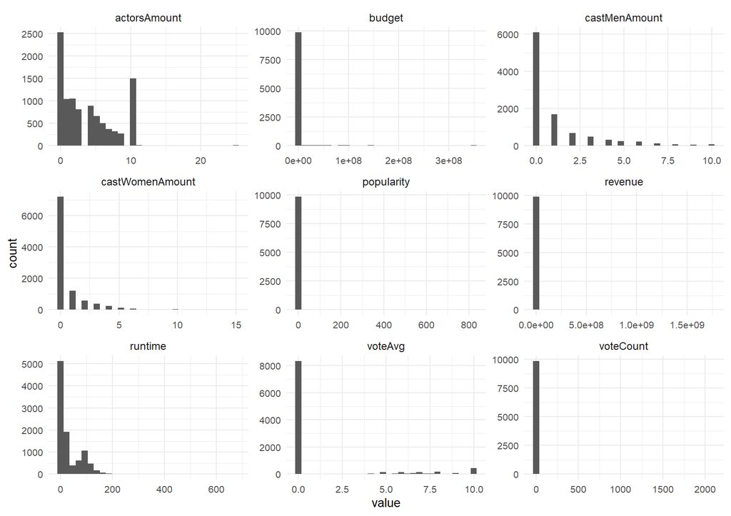

**Explicación:**  
Los histogramas ayudan a ver cómo se distribuye cada variable (si está muy cargada a un lado, si hay valores extremos, etc.).

#### Histogramas en escala log (solo para variables muy grandes)

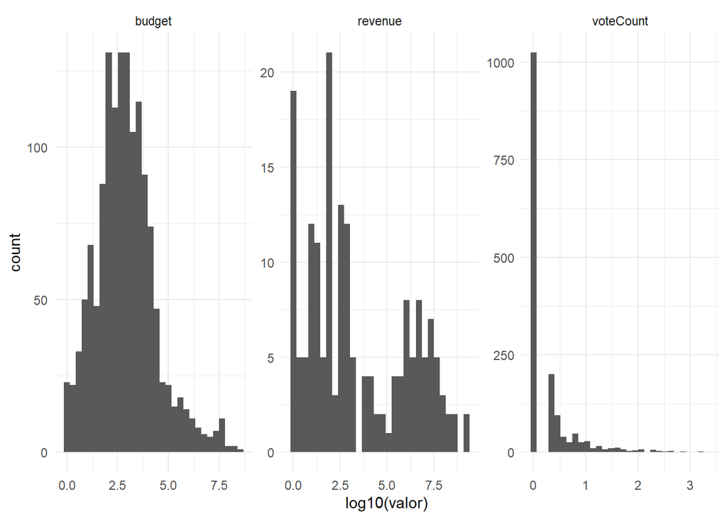

**Explicación:**  
Como presupuesto/ingresos/votos tienen valores enormes, la escala log nos deja ver mejor el patrón sin que todo se aplaste por unos pocos valores muy altos.

#### Prueba de normalidad (Lilliefors)

Prueba de normalidad de Lilliefors por variable

| variable | p_value | normalidad |
| --- | --- | --- |
| popularity | 0 | No normal |
| budget | 0 | No normal |
| revenue | 0 | No normal |
| runtime | 0 | No normal |
| voteAvg | 0 | No normal |
| voteCount | 0 | No normal |
| actorsAmount | 0 | No normal |
| castWomenAmount | 0 | No normal |
| castMenAmount | 0 | No normal |

**Conclusión:**  
Si el **p-value < 0.05**, se rechaza la normalidad. En este dataset, la mayoría de variables cuantitativas dan p-values muy pequeños, así que **no siguen una distribución normal**.

### 3.2 Variables cualitativas

> Nota: Para no hacer el reporte eterno, se muestra **Top 10 + Otros** cuando hay muchas categorías.

#### Tablas de frecuencia

**Idioma original (originalLanguage)**

Top 10 idiomas originales

| Idioma original | Frecuencia | Porcentaje (%) |
| --- | --- | --- |
| en | 4194 | 42.40 |
| fr | 824 | 8.33 |
| es | 814 | 8.23 |
| pt | 585 | 5.91 |
| de | 377 | 3.81 |
| zh | 246 | 2.49 |
| ja | 224 | 2.26 |
| it | 203 | 2.05 |
| nl | 174 | 1.76 |
| ko | 169 | 1.71 |

**Explicación:**  
Aquí se observa qué idiomas aparecen más en el dataset. Generalmente pocos idiomas dominan y los demás son menos frecuentes.

**Género principal (main_genre) – Top 10 + Otros**

Frecuencia de géneros principales (Top 10 + Otros)

| Género principal | Frecuencia | Porcentaje (%) |
| --- | --- | --- |
| Documentary | 1987 | 24.90 |
| Drama | 1932 | 24.21 |
| Comedy | 1122 | 14.06 |
| Otros | 672 | 8.42 |
| Horror | 616 | 7.72 |
| Animation | 436 | 5.46 |
| Thriller | 301 | 3.77 |
| Music | 275 | 3.45 |
| Romance | 264 | 3.31 |
| Action | 243 | 3.05 |
| Science Fiction | 132 | 1.65 |

**Explicación:**  
Se usa el **género principal** (el primero) para resumir mejor. Normalmente pocos géneros concentran gran parte de las películas.

**Videos promocionales (video)**

Tabla de frecuencias de videos promocionales

| Video promocional | Frecuencia | Porcentaje (%) |
| --- | --- | --- |
| No | 9892 | 100 |

**Explicación:**  
Se separa “Desconocido” cuando falta el dato, para no mezclarlo con un “No”.

**País de producción (productionCountry_main) – Top 10 + Otros**

Frecuencia de países de producción (Top 10 + Otros)

| País de producción | Frecuencia | Porcentaje (%) |
| --- | --- | --- |
| Otros | 2709 | 43.34 |
| US | 917 | 14.67 |
| FR | 460 | 7.36 |
| GB | 386 | 6.18 |
| DE | 349 | 5.58 |
| BR | 332 | 5.31 |
| IN | 322 | 5.15 |
| CA | 222 | 3.55 |
| ES | 199 | 3.18 |
| AR | 184 | 2.94 |
| ID | 171 | 2.74 |

**Conclusión:**  
En general, las cualitativas no se reparten parejo: hay categorías que dominan y luego una “cola” larga de categorías raras. Por eso Top 10 + Otros es una forma práctica de resumir.

## Ejercicio 5 (Puntos extra)

> 6 preguntas nuevas propuestas para explorar el dataset (y ganar puntos extra).

### 5.1 ¿Qué idiomas tienen mayor ingreso promedio?

Top 10 idiomas por ingreso promedio (n>=20)

| originalLanguage | avg_revenue | n |
| --- | --- | --- |
| en | 55094032 | 83 |

**Explicación:**  
Se filtra por n>=20 para que no gane un idioma con muy pocas películas.

### 5.2 ¿Más géneros (genresAmount) se asocia con más ingresos?

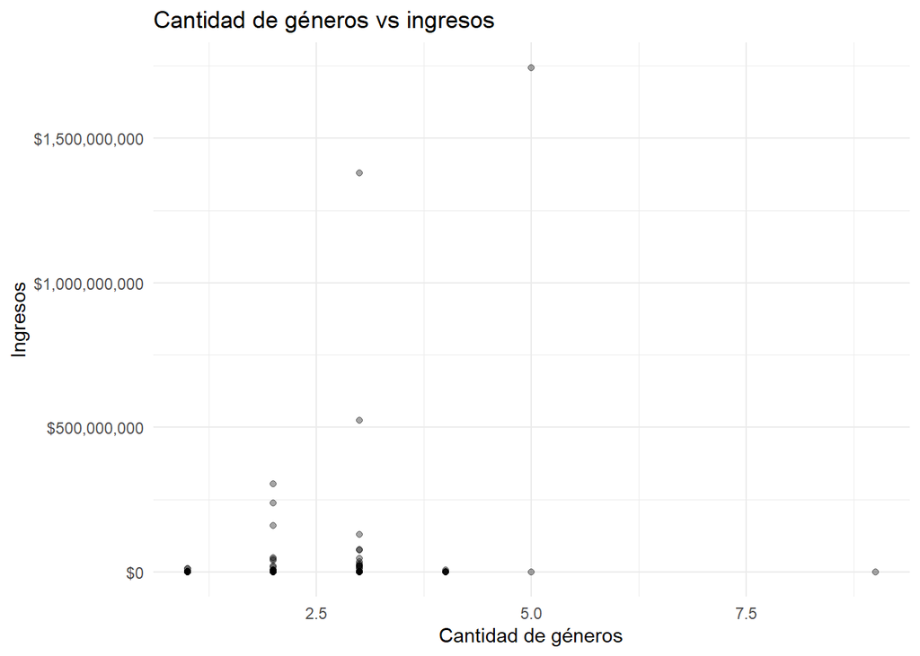

```
## [1] 0.04905602
```

**Explicación:**  
Esto sirve para ver si películas “más mezcladas” en géneros tienden a generar más taquilla.

### 5.3 ¿Qué tan común es tener homepage por año?

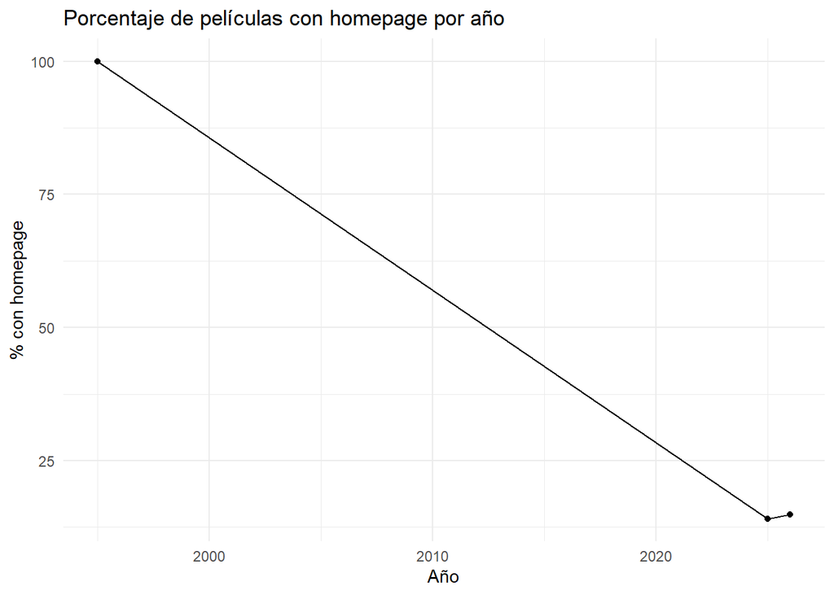

**Explicación:**  
Muestra si con el tiempo se vuelve más común que una película tenga página oficial registrada.

### 5.4 ¿Cómo cambia la popularidad promedio por año?

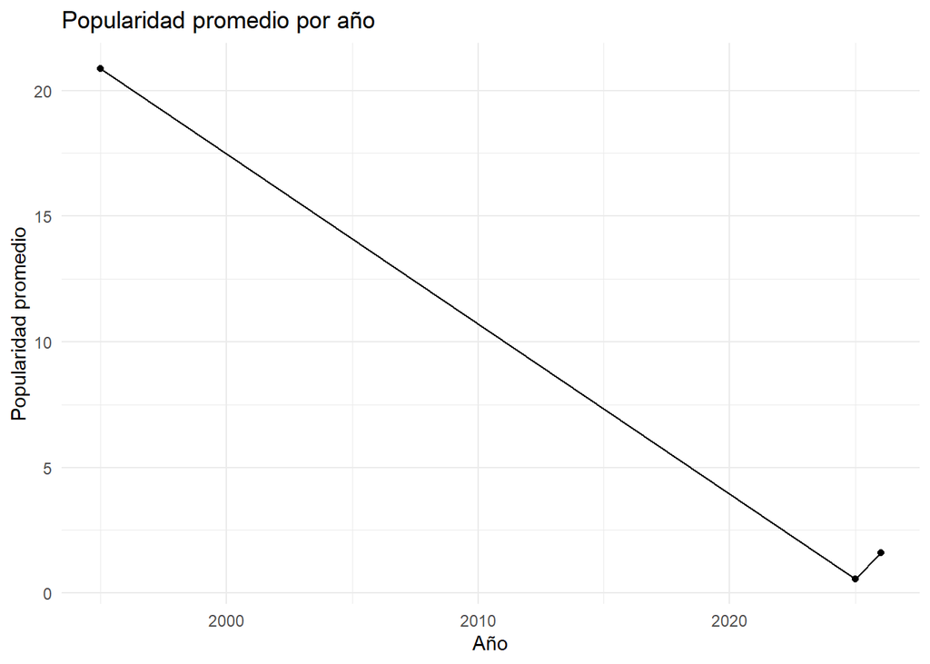

**Explicación:**  
Sirve para ver si el dataset refleja años con películas más “populares” en promedio.

### 5.5 ¿Runtime se relaciona con voteAvg?

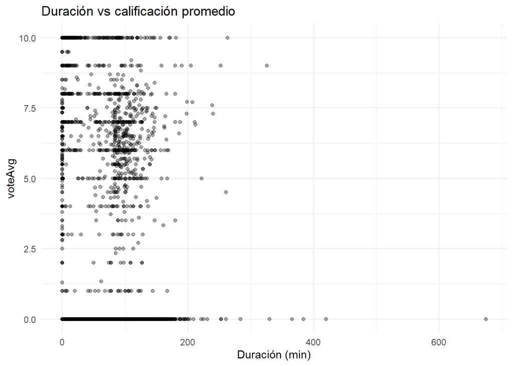

```
## [1] 0.1144645
```

**Explicación:**  
Ayuda a ver si películas más largas tienden a ser mejor o peor calificadas.

### 5.6 ¿Qué países tienen mejor calificación promedio?

Top 10 países por calificación promedio (n>=20, voteCount>100)

| productionCountry_main | avg_vote | n |
| --- | --- | --- |
| US | 6.59719 | 21 |

**Explicación:**  
Se filtra por cantidad mínima de películas y votos para que sea más justo el ranking.